# Assignment 9: Graduate School Admissions

Kauner Urmston

2026-04-05

```r
library(tidyverse)
library(modelr)
library(easystats)
admissions <- read_csv("../../Data/GradSchool_Admissions.csv")
glimpse(admissions)
```

```
## Rows: 400
## Columns: 4
## $ admit <dbl> 0, 1, 1, 1, 0, 1, 1, 0, 1, 0, 0, 0, 1, 0, 1, 0, 0, 0, 0, 1, 0, 1…
## $ gre   <dbl> 380, 660, 800, 640, 520, 760, 560, 400, 540, 700, 800, 440, 760,…
## $ gpa   <dbl> 3.61, 3.67, 4.00, 3.19, 2.93, 3.00, 2.98, 3.08, 3.39, 3.92, 4.00…
## $ rank  <dbl> 3, 3, 1, 4, 4, 2, 1, 2, 3, 2, 4, 1, 1, 2, 1, 3, 4, 3, 2, 1, 3, 2…
```

```r
names(admissions)
```

```
## [1] "admit" "gre"   "gpa"   "rank"
```

```r
admissions <- admissions %>%
  drop_na() %>%
  mutate(
    admit = as.factor(admit),
    rank = as.factor(rank)
  )

glimpse(admissions)
```

```
## Rows: 400
## Columns: 4
## $ admit <fct> 0, 1, 1, 1, 0, 1, 1, 0, 1, 0, 0, 0, 1, 0, 1, 0, 0, 0, 0, 1, 0, 1…
## $ gre   <dbl> 380, 660, 800, 640, 520, 760, 560, 400, 540, 700, 800, 440, 760,…
## $ gpa   <dbl> 3.61, 3.67, 4.00, 3.19, 2.93, 3.00, 2.98, 3.08, 3.39, 3.92, 4.00…
## $ rank  <fct> 3, 3, 1, 4, 4, 2, 1, 2, 3, 2, 4, 1, 1, 2, 1, 3, 4, 3, 2, 1, 3, 2…
```

```r
count(admissions, admit)
```

```
## # A tibble: 2 × 2
##   admit     n
##   <fct> <int>
## 1 0       273
## 2 1       127
```

```r
count(admissions, rank)
```

```
## # A tibble: 4 × 2
##   rank      n
##   <fct> <int>
## 1 1        61
## 2 2       151
## 3 3       121
## 4 4        67
```

```r
summary(admissions)
```

```
##  admit        gre             gpa        rank
##  0:273   Min.   :220.0   Min.   :2.260   1: 61
##  1:127   1st Qu.:520.0   1st Qu.:3.130   2:151
##          Median :580.0   Median :3.395   3:121
##          Mean   :587.7   Mean   :3.390   4: 67
##          3rd Qu.:660.0   3rd Qu.:3.670
##          Max.   :800.0   Max.   :4.000
```

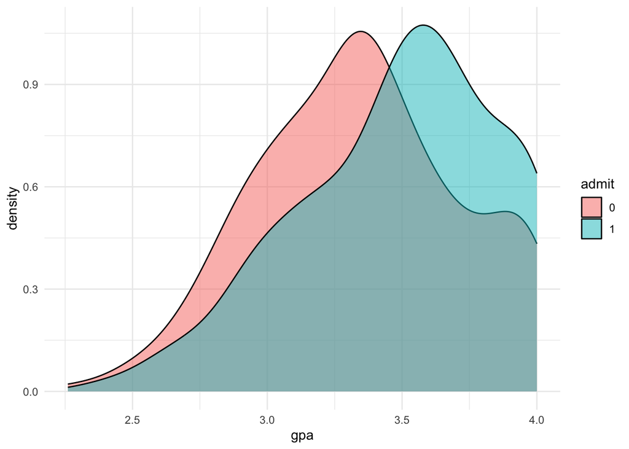

```r
admissions %>%
  ggplot(aes(x = gpa, fill = admit)) +
  geom_density(alpha = 0.5) +
  theme_minimal()
```

```r
mod1 <- glm(admit ~ gre, data = admissions, family = binomial)
mod2 <- glm(admit ~ gpa, data = admissions, family = binomial)
mod3 <- glm(admit ~ rank, data = admissions, family = binomial)
mod4 <- glm(admit ~ gre + gpa, data = admissions, family = binomial)
mod5 <- glm(admit ~ gre + gpa + rank, data = admissions, family = binomial)
```

```r
compare_performance(mod1, mod2, mod3, mod4, mod5, rank = TRUE)
```

```
## # Comparison of Model Performance Indices
##
## Name | Model | Tjur's R2 |  RMSE | Sigma | Log_loss | Score_log
## ---------------------------------------------------------------
## mod5 |   glm |     0.102 | 0.441 | 1.079 |    0.573 |   -50.755
## mod3 |   glm |     0.063 | 0.451 | 1.095 |    0.594 |   -49.265
## mod4 |   glm |     0.047 | 0.455 | 1.100 |    0.600 |   -48.679
## mod1 |   glm |     0.034 | 0.458 | 1.105 |    0.608 |   -48.247
## mod2 |   glm |     0.032 | 0.458 | 1.106 |    0.609 |   -48.163
##
## Name | Score_spherical |   PCP | AIC weights | AICc weights | BIC weights | Performance-Score
## ---------------------------------------------------------------------------------------------
## mod5 |           0.004 | 0.611 |       0.998 |        0.997 |       0.655 |            70.93%
## mod3 |           0.010 | 0.594 |       0.002 |        0.002 |       0.070 |            38.79%
## mod4 |           0.004 | 0.587 |    3.65e-04 |     3.94e-04 |       0.095 |            26.15%
## mod1 |           0.003 | 0.581 |    5.70e-05 |     6.25e-05 |       0.110 |            20.94%
## mod2 |           0.004 | 0.581 |    3.62e-05 |     3.96e-05 |       0.070 |            20.91%
```

```r
summary(mod5)
```

```
##
## Call:
## glm(formula = admit ~ gre + gpa + rank, family = binomial, data = admissions)
##
## Deviance Residuals:
##     Min       1Q   Median       3Q      Max
## -1.6268  -0.8662  -0.6388   1.1490   2.0790
##
## Coefficients:
##              Estimate Std. Error z value Pr(>|z|)
## (Intercept) -3.989979   1.139951  -3.500 0.000465 ***
## gre          0.002264   0.001094   2.070 0.038465 *
## gpa          0.804038   0.331819   2.423 0.015388 *
## rank2       -0.675443   0.316490  -2.134 0.032829 *
## rank3       -1.340204   0.345306  -3.881 0.000104 ***
## rank4       -1.551464   0.417832  -3.713 0.000205 ***
## ---
## Signif. codes:  0 '***' 0.001 '**' 0.01 '*' 0.05 '.' 0.1 ' ' 1
##
## (Dispersion parameter for binomial family taken to be 1)
##
##     Null deviance: 499.98  on 399  degrees of freedom
## Residual deviance: 458.52  on 394  degrees of freedom
## AIC: 470.52
##
## Number of Fisher Scoring iterations: 4
```

```r
model_parameters(mod5)
```

```
## Parameter   | Log-Odds |       SE |         95% CI |     z |      p
## -------------------------------------------------------------------
## (Intercept) |    -3.99 |     1.14 | [-6.27, -1.79] | -3.50 | < .001
## gre         | 2.26e-03 | 1.09e-03 | [ 0.00,  0.00] |  2.07 | 0.038
## gpa         |     0.80 |     0.33 | [ 0.16,  1.46] |  2.42 | 0.015
## rank [2]    |    -0.68 |     0.32 | [-1.30, -0.06] | -2.13 | 0.033
## rank [3]    |    -1.34 |     0.35 | [-2.03, -0.67] | -3.88 | < .001
## rank [4]    |    -1.55 |     0.42 | [-2.40, -0.75] | -3.71 | < .001
```

```
##
## Uncertainty intervals (profile-likelihood) and p-values (two-tailed)
##   computed using a Wald z-distribution approximation.
```

```
##
## The model has a log- or logit-link. Consider using `exponentiate =
##   TRUE` to interpret coefficients as ratios.
```

## Model Interpretation

The logistic regression model including GRE, GPA, and undergraduate institution rank provided the best fit to the data. Both GRE and GPA had significant positive effects on admission probability, indicating that higher test scores and academic performance increase the likelihood of being admitted to graduate school.

In contrast, the rank of the undergraduate institution had a significant negative effect on admission. Compared to students from top-tier institutions (rank 1), students from lower-ranked institutions (ranks 2, 3, and 4) had reduced odds of admission. The magnitude of this effect increased as institutional rank decreased, suggesting that attending a lower-ranked undergraduate institution substantially lowers the probability of acceptance.

Overall, the results indicate that both academic performance and institutional prestige play important roles in graduate school admissions.

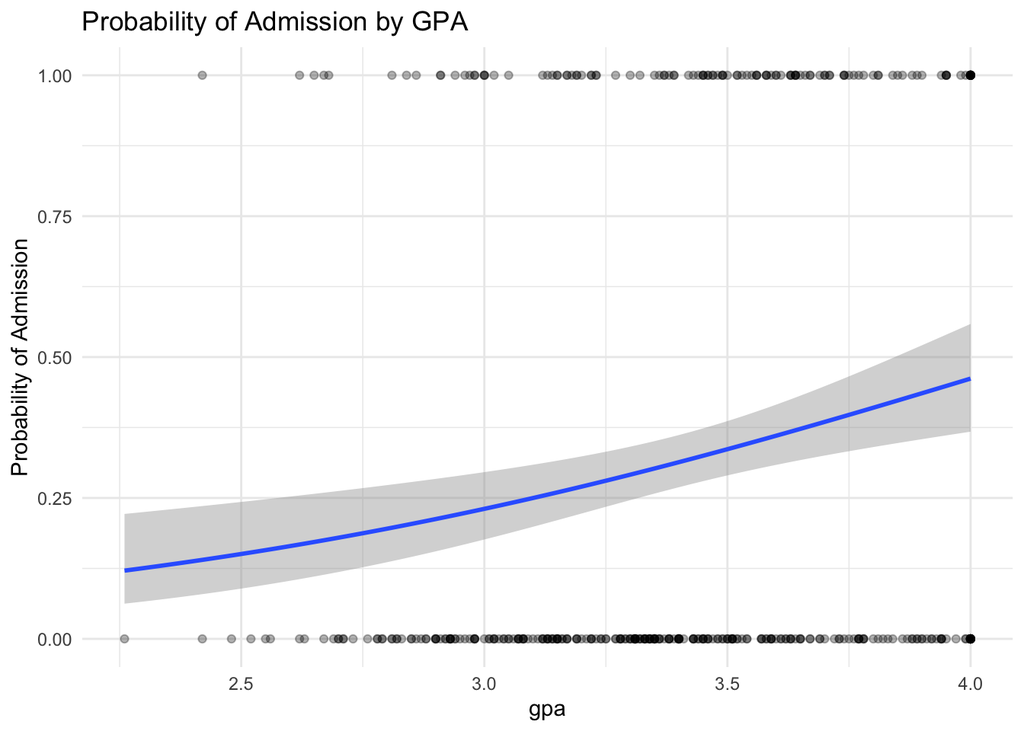

```r
admissions %>%
  ggplot(aes(x = gpa, y = as.numeric(as.character(admit)))) +
  geom_point(alpha = 0.3) +
  geom_smooth(method = "glm", method.args = list(family = "binomial")) +
  theme_minimal() +
  labs(
    title = "Probability of Admission by GPA",
    y = "Probability of Admission"
  )
```

## Conclusion

This analysis explored the factors influencing graduate school admission using logistic regression models. Among the models tested, the combination of GRE score, GPA, and undergraduate institution rank provided the best performance.

Higher GRE scores and GPAs were associated with increased probability of admission, while attending a lower-ranked undergraduate institution significantly decreased admission odds. These findings suggest that both academic achievement and institutional prestige are important predictors of graduate school acceptance.

The modeling process demonstrated the importance of comparing multiple models and selecting one that balances predictive performance and interpretability.